# Application of ComBat-seq on simulated datasets

DE - turn off EB shrinkage

Yuqing Zhang

March 21, 2019

## ComBat-seq model

We developed a negative binomial GLM for adjusting for batch effect in count data. Gene-wise linear model:

$$\log(\mu_{gij}) = \alpha_g + X_j^T\beta_g + \gamma_{gi} + \log(N_j) \\
var(y_{gij}) = \mu_{gij} + \phi_{gi}\mu_{gij}^2$$

- $y_{gij}$: Counts of gene $g$ in sample $j$ from batch $i$.
- $\mu_{gij}$: Expectation of counts of gene $g$ in sample $j$ from batch $i$.
- $\alpha_g$: Background expression of gene $g$.
- $X_j^T\beta_g$: Biological condition effect of sample $j$, design matrix and corresponding coefficients.
- $\gamma_{gi}$: Mean batch parameter for batch $i$ on gene $g$.
- $\phi_{gi}$: Dispersion batch parameter for batch $i$ on gene $g$.
- $N_j$: Library size (total number of counts) in sample $j$.

## Simulation setup

We test how well ComBat-seq performs, compared to using other methods to address batch effect, in differential expression analysis. Our primary study design is:

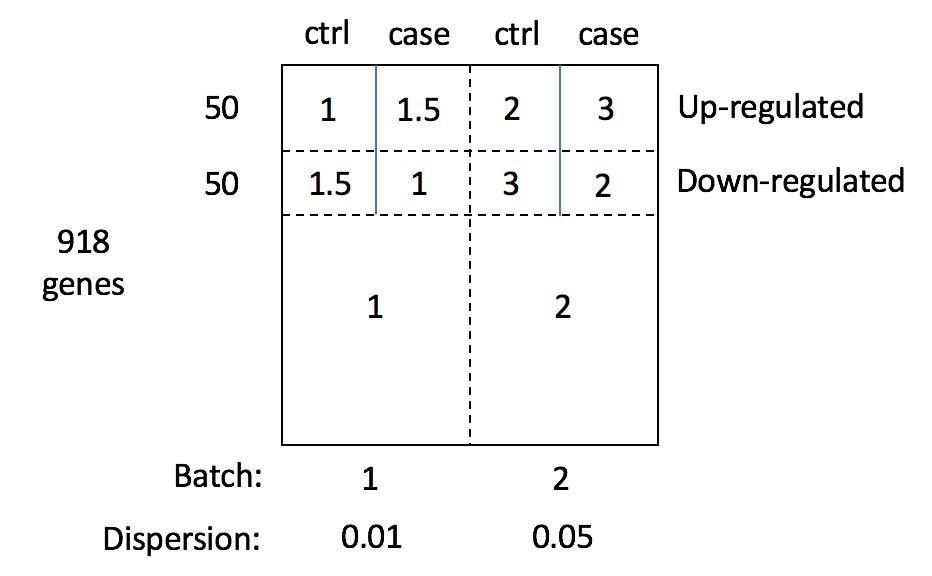

In this design, we assume that batch effect is in the form of both **fold changes in the average of counts** and **differences in dispersion** across batches. We also simulate the count matrix using the *polyester* package, which is convenient because it uses the negative binomial model of edgeR. These are consistant with our ComBat-seq model assumptions.

We perform DE with edgeR, and compare TPR and FPR in the following 3 settings:

- original counts, not including batch as a covariate
- original counts, with batch included as a covariate
- counts adjusted by ComBat-seq

Several factors can affect the performance of DE detection:

- Fold change of counts caused by batch / condition (mean batch effect)
- Dispersion differences (variance batch effect)
- Balanced / unbalanced study design
- Number of samples in total, and in batch / condition groups
- Number of reads per gene (sequencing depth)

We systematically evaluate ComBat-seq in different combinations of these factors, to see whether / when ComBat-seq works better than including batch as a covariate in edgeR.

## Systematic evaluation

Boxplots show distributions of TPR and FPR from 100 simulations.

Setup start point:

- Fold changes: Biological - 1.5, Batch - 1.5
- Dispersion: Batch 1 - 0.01, Batch 2 - 0.1
- Study design: Balanced
- Number of samples: 20 in total
- Reads per gene: Median 120 (coverage 5)

Note that this setup was arbitrarily selected - based on my exploration of real count data, it seems a okay place to start. Based on this setup, we vary each factor in turn, while keeping all the other factors fixed.

### Fold change of counts caused by batch / condition

Test fold change of counts at these levels:

|  | Fold change 1 | Fold change 2 | Fold change 3 | Fold change 4 |
| --- | --- | --- | --- | --- |
| Biological | 1.5 | 1.5 | 1.5 | 1.5 |
| Batch | 1 | 1.5 | 2 | 3 |

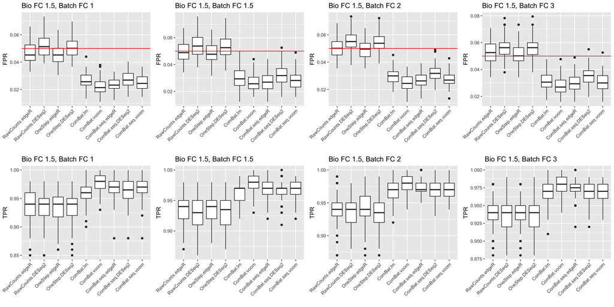

### Dispersion differences

Test dispersion differences across batch at these levels:

|  | Dispersion 1 | Dispersion 2 | Dispersion 3 | Dispersion 4 |
| --- | --- | --- | --- | --- |
| Batch1 | 1 | 0.1 | 0.01 | 0.001 |
| Batch2 | 0.1 | 0.1 | 0.1 | 0.1 |

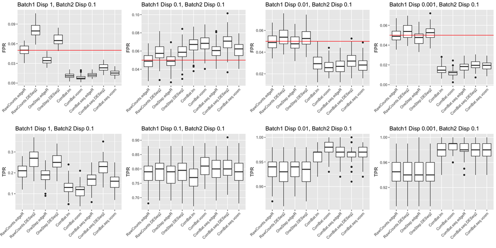

### Sample size

Test sample sizes at these levels:

|  | Sample size 1 | Sample size 2 | Sample size 3 |
| --- | --- | --- | --- |
|  | 10 | 20 | 40 |

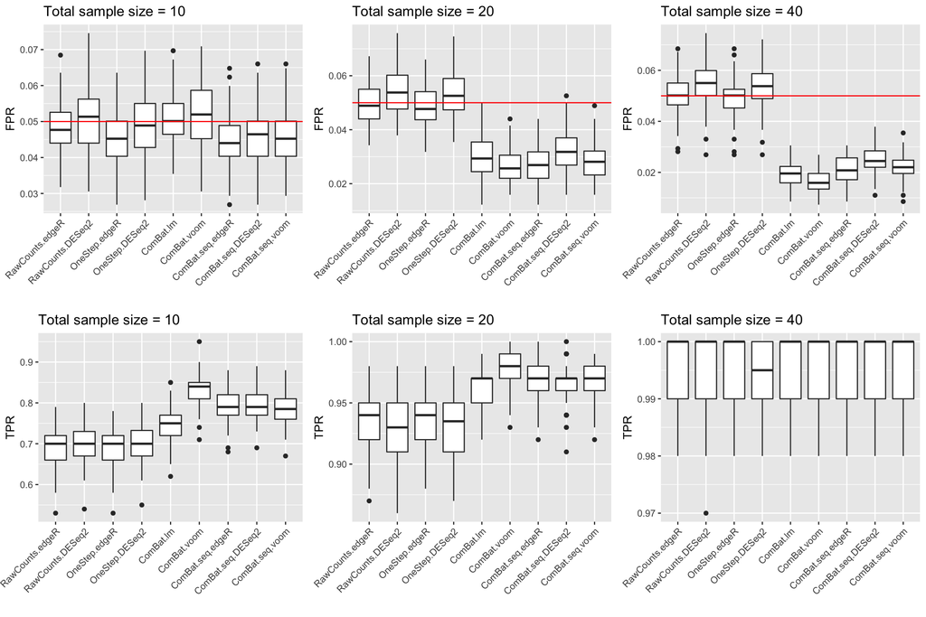

### Study design

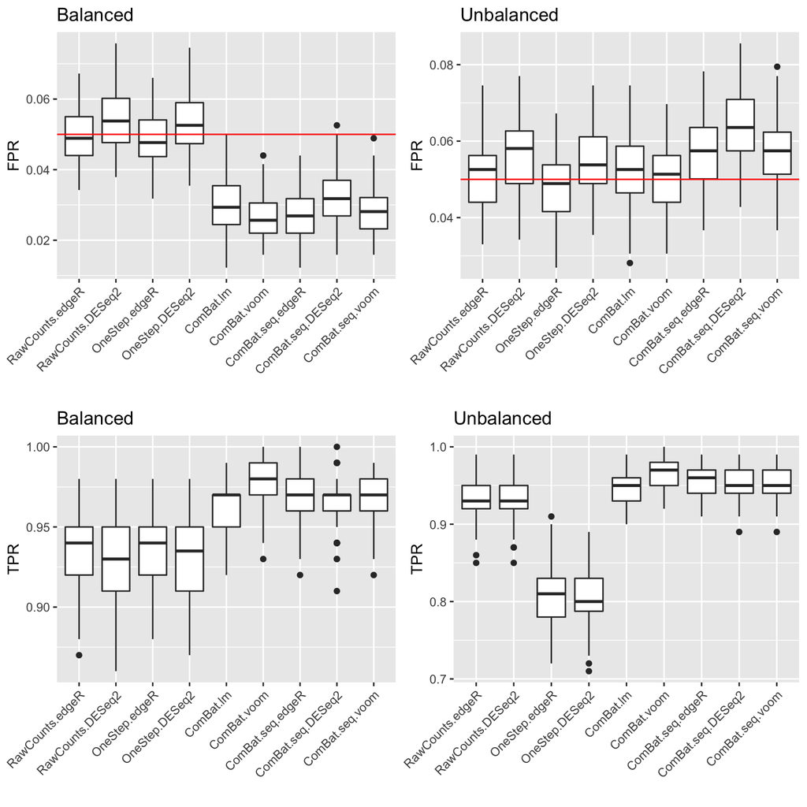

### Sequencing depth

Test reads per gene at these levels:

|  | Median reads per gene 1 | Median reads per gene 2 | Median reads per gene 3 | Median reads per gene 4 |
| --- | --- | --- | --- | --- |
|  | 24 | 120 | 240 | 480 |

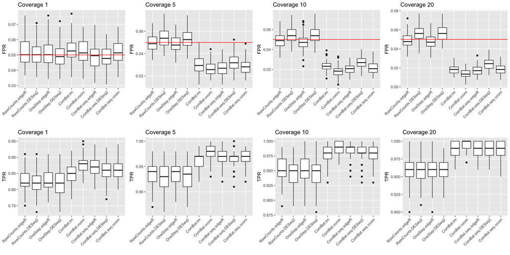